# NLP with Disaster Tweets using RNN Techniques:

#### Table of Contents:

- Intoduction
- Brief Description of the Problem and Data
- Exploratory Data Analysis
- Model Architecure
  - LSTM
  - GRU
- Results and Analysis
- Conclusion

## Introduction:

Natural disasters can have devastating impacts, both in terms of human lives and economic losses. Early detection of these events can be crucial in preventing their devastating consequences and one of the most promising technologies in this regard is the analysis of tweets on Twitter. There are several advantages in using Social Media to get help in this kind of situations, such as their ability to quickly provide a large amount of data, their global reach, and their ability to capture more spontaneous reactions from users, and Twitter is amongst the most popular. This makes it an invaluable tool for disaster detection, as it can provide information about the scale and severity of events much more quickly than traditional methods. By using Twitter for disaster detection, emergency responders can act more quickly and effectively in response to disasters, thus reducing their devastating impacts.

```python
# Import libraries:

import pandas as pd
import numpy as np
import random
import math
import string
import os


# To create models and evaluation:
import sklearn
from sklearn.model_selection import train_test_split
from sklearn import metrics
from sklearn.metrics import accuracy_score, precision_score, recall_score, classification_report, confusion_matrix


# To work with Text:
import re
import nltk
nltk.download(['punkt', 'stopwords', 'wordnet', 'averaged_perceptron_tagger', 'omw-1.4'])
from nltk.tokenize import word_tokenize, WordPunctTokenizer
from nltk.corpus import stopwords
from nltk.stem.wordnet import WordNetLemmatizer
from nltk.stem import PorterStemmer


# To create models:
import tensorflow as tf
from tensorflow import keras
from keras.preprocessing.text import Tokenizer
from tensorflow.keras.preprocessing.sequence import pad_sequences
from tensorflow.keras.layers import Input, Dense, Embedding, Dropout, LSTM, GRU, Bidirectional
from tensorflow.keras.models import Sequential, Model
from tensorflow.keras.optimizers import Adam


# Visualization:
import matplotlib.pyplot as plt
import seaborn as sb
%matplotlib inline


# To avoid warning:
import warnings
warnings.filterwarnings('ignore')
```

```
2023-02-22 14:12:52.933444: I tensorflow/core/platform/cpu_feature_guard.cc:193] This TensorFlow binary is optimized with oneAPI Deep Neural Network Library (oneDNN) to use the following CPU instructions in performance-critical operations:  AVX2 FMA
To enable them in other operations, rebuild TensorFlow with the appropriate compiler flags.
```

## Brief Description of the Problem and Data:

In this Notebook, we focused on trying to be able to differentiate between a regular, random Tweet from an one that is about a Natural Disaster.

The main aim for this Notebook is to start practicing with Natural Language Processing, starting from the preprocessing phase all the way to the evaluation of the results phase.

There are 7613 entries (or rows) and five columns: id, keyword, location, text, target. The text column holds the tweet text which we will need to evaluate. We see that the text cells contain all sorts of characters such as lowercase letters, uppercase letters, numbers, punctuation, hastags (#), etc.

The Target is whether or not the text/tweet is a real disaster or not.

```python
# Get training data:

train_data = pd.read_csv('trains.csv', sep = ',')
train_data.head()
```

|  | id | keyword | location | text | target |
| --- | --- | --- | --- | --- | --- |
| 0 | 1 | NaN | NaN | Our Deeds are the Reason of this #earthquake M... | 1 |
| 1 | 4 | NaN | NaN | Forest fire near La Ronge Sask. Canada | 1 |
| 2 | 5 | NaN | NaN | All residents asked to 'shelter in place' are ... | 1 |
| 3 | 6 | NaN | NaN | 13,000 people receive #wildfires evacuation or... | 1 |
| 4 | 7 | NaN | NaN | Just got sent this photo from Ruby #Alaska as ... | 1 |

```python
# dataset:

train_data.sample(10)
```

|  | id | keyword | location | text | target |
| --- | --- | --- | --- | --- | --- |
| 5533 | 7893 | quarantined | rome | Top link: Reddit's new content policy goes int... | 0 |
| 1272 | 1834 | burned | Belleville, Illinois | Sure I just burned about 100 calories after ea... | 0 |
| 5026 | 7167 | mudslide | London | @SophieWisey I couldn't. #mudslide | 1 |
| 7587 | 10841 | NaN | NaN | Sirens everywhere! | 0 |
| 143 | 205 | airplane%20accident | Hyderabad Telangana INDIA | Horrible Accident Man Died In Wings of Airpla... | 1 |
| 1024 | 1486 | body%20bags | CA | BESTSELLER! Fossil Dawson Mini Cross Body Bag ... | 0 |
| 2278 | 3266 | demolish | Wema building | Enugu Government to demolish illegal structure... | 0 |
| 5592 | 7980 | razed | North | @petereallen @HuffPostUK @bbc5live How signifi... | 0 |
| 4243 | 6030 | hazardous | Canada | Skinny Jeans are Hazardous for Your Health! #s... | 1 |
| 6171 | 8801 | sirens | Nomad, USA | Fuck Sleeping With Sirens. | 0 |

```python
# Size of the dataset:

train_data.shape
```

```
(7613, 5)
```

```python
# Checking null values:

train_data.isnull().sum()
```

```
id             0
keyword       61
location    2533
text           0
target         0
dtype: int64
```

```python
# Info data:

train_data.info()
```

```
<class 'pandas.core.frame.DataFrame'>
RangeIndex: 7613 entries, 0 to 7612
Data columns (total 5 columns):
 #   Column    Non-Null Count  Dtype
---  ------    --------------  -----
 0   id        7613 non-null   int64
 1   keyword   7552 non-null   object
 2   location  5080 non-null   object
 3   text      7613 non-null   object
 4   target    7613 non-null   int64
dtypes: int64(2), object(3)
memory usage: 297.5+ KB
```

```python
# Describe data:

train_data.describe()
```

|  | id | target |
| --- | --- | --- |
| count | 7613.000000 | 7613.00000 |
| mean | 5441.934848 | 0.42966 |
| std | 3137.116090 | 0.49506 |
| min | 1.000000 | 0.00000 |
| 25% | 2734.000000 | 0.00000 |
| 50% | 5408.000000 | 0.00000 |
| 75% | 8146.000000 | 1.00000 |
| max | 10873.000000 | 1.00000 |

```python
# Describe data with object:

train_data.describe(include = 'object')
```

|  | keyword | location | text |
| --- | --- | --- | --- |
| count | 7552 | 5080 | 7613 |
| unique | 221 | 3341 | 7503 |
| top | fatalities | USA | 11-Year-Old Boy Charged With Manslaughter of T... |
| freq | 45 | 104 | 10 |

## Exploratory Data Analysis (EDA) - Inspect, Visualize and Clean the Data:

First, it is important to note from above that we are not missing any values from the text and target columns. This will make it easier when preprocessing the data for the model. Below we can visualize the data to get a better understanding of it.

```python
# counts of variable 'keyword':

train_data.keyword.value_counts()
```

```
fatalities               45
deluge                   42
armageddon               42
sinking                  41
damage                   41
                         ..
forest%20fire            19
epicentre                12
threat                   11
inundation               10
radiation%20emergency     9
Name: keyword, Length: 221, dtype: int64
```

```python
# counts of variable 'location':

train_data.location.value_counts()[:20]
```

```
USA                104
New York            71
United States       50
London              45
Canada              29
Nigeria             28
UK                  27
Los Angeles, CA     26
India               24
Mumbai              22
Washington, DC      21
Kenya               20
Worldwide           19
Australia           18
Chicago, IL         18
California          17
Everywhere          15
New York, NY        15
California, USA     15
Florida             14
Name: location, dtype: int64
```

```python
# Check duplicate values:

print(train_data.id.nunique())

print(sum(train_data.keyword.duplicated()))
print(sum(train_data.location.duplicated()))
print(sum(train_data.text.duplicated()))
```

```
7613
7391
4271
110
```

```python
# Check duplicate values:

train_data[train_data.duplicated(['text'])]
```

|  | id | keyword | location | text | target |
| --- | --- | --- | --- | --- | --- |
| 48 | 68 | ablaze | Live On Webcam | Check these out: http://t.co/rOI2NSmEJJ http:/... | 0 |
| 115 | 165 | aftershock | US | 320 [IR] ICEMOON [AFTERSHOCK] \| http://t.co/vA... | 0 |
| 119 | 172 | aftershock | Switzerland | 320 [IR] ICEMOON [AFTERSHOCK] \| http://t.co/TH... | 0 |
| 164 | 238 | airplane%20accident | NaN | Experts in France begin examining airplane deb... | 1 |
| 624 | 898 | bioterrorism | NaN | To fight bioterrorism sir. | 0 |
| ... | ... | ... | ... | ... | ... |
| 7600 | 10855 | NaN | NaN | Evacuation order lifted for town of Roosevelt:... | 1 |
| 7607 | 10867 | NaN | NaN | #stormchase Violent Record Breaking EF-5 El Re... | 1 |
| 7609 | 10870 | NaN | NaN | @aria_ahrary @TheTawniest The out of control w... | 1 |
| 7610 | 10871 | NaN | NaN | M1.94 [01:04 UTC]?5km S of Volcano Hawaii. htt... | 1 |
| 7611 | 10872 | NaN | NaN | Police investigating after an e-bike collided ... | 1 |

110 rows × 5 columns

```python
# Check duplicate values:

print(train_data.text[48])
print(train_data.text[115])
print(train_data.text[119])
```

```
Check these out: http://t.co/rOI2NSmEJJ http://t.co/3Tj8ZjiN21 http://t.co/YDUiXEfIpE http://t.co/LxTjc87KLS #nsfw
320 [IR] ICEMOON [AFTERSHOCK] | http://t.co/vAM5POdGyw | @djicemoon | #Dubstep #TrapMusic #DnB #EDM #Dance #IcesÛ_ http://t.co/zEVakJaPcz
320 [IR] ICEMOON [AFTERSHOCK] | http://t.co/THyzOMVWU0 | @djicemoon | #Dubstep #TrapMusic #DnB #EDM #Dance #IcesÛ_ http://t.co/83jOO0xk29
```

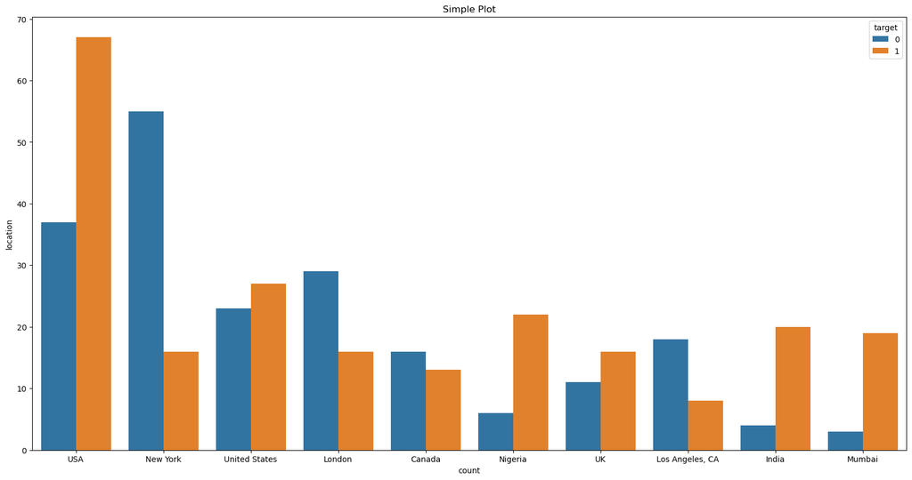

```python
# Visualize location:

plt.figure(figsize = [20, 10])

sb.countplot(data = train_data, x = 'location', order = train_data['location'].value_counts()[:10].index, hue = 'target');
plt.title('Simple Plot');
plt.xlabel('count');
plt.ylabel('location');
```

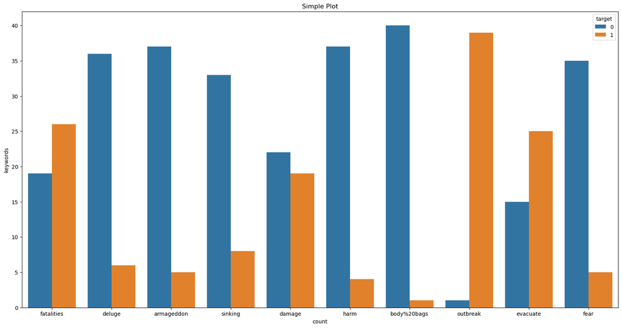

```python
# Visualize keyword:

plt.figure(figsize = [20, 10])

sb.countplot(data = train_data, x = 'keyword', order = train_data['keyword'].value_counts()[:10].index, hue = 'target');
plt.title('Simple Plot');
plt.xlabel('count');
plt.ylabel('keywords');
```

```
0    4342
1    3271
Name: target, dtype: int64
```

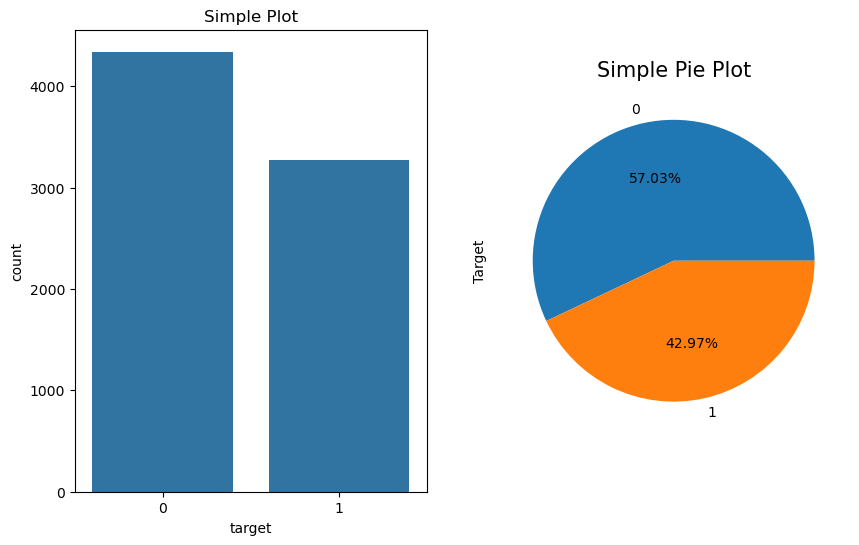

```python
# Visualize target:

plt.figure(figsize = [10, 6])

color = sb.color_palette()[0]

labels = train_data.target.value_counts()
print(labels)

plt.subplot(1, 2, 1)
sb.countplot(data = train_data, x = 'target', color = color);
plt.title('Simple Plot');
plt.ylabel('count');
plt.xlabel('target');

plt.subplot(1, 2, 2)
labels.plot(kind = 'pie',autopct = '%1.2f%%', shadow = False, startangle = 0)
plt.title('Simple Pie Plot',fontsize = 15)
plt.ylabel('Target',fontsize = 10);
```

```python
# Check location's count for target == 1:

train_data.query(' target == 1 ')['location'].value_counts()[:20]
```

```
USA                 67
United States       27
Nigeria             22
India               20
Mumbai              19
UK                  16
London              16
New York            16
Washington, DC      15
Canada              13
Worldwide           12
Washington, D.C.     9
Chicago, IL          9
Australia            9
Indonesia            8
Los Angeles, CA      8
California, USA      8
Earth                8
California           7
New York, NY         7
Name: location, dtype: int64
```

```python
# Check location's count for target == 0:

train_data.query(' target == 0 ')['location'].value_counts()[:20]
```

```
New York           55
USA                37
London             29
United States      23
Los Angeles, CA    18
Canada             16
Kenya              15
Everywhere         12
Florida            11
UK                 11
California         10
NYC                10
United Kingdom     10
ss                  9
London, England     9
Australia           9
Chicago, IL         9
304                 9
San Francisco       8
New York, NY        8
Name: location, dtype: int64
```

```python
# Check keyword's count for target == 1:

train_data.query(' target == 1 ')['keyword'].value_counts()[:20]
```

```
derailment               39
wreckage                 39
outbreak                 39
debris                   37
oil%20spill              37
typhoon                  37
evacuated                32
suicide%20bombing        32
rescuers                 32
suicide%20bomb           32
nuclear%20disaster       31
razed                    31
suicide%20bomber         30
earthquake               30
airplane%20accident      30
collision                29
wildfire                 29
bridge%20collapse        29
evacuation               28
buildings%20on%20fire    28
Name: keyword, dtype: int64
```

```python
# Check keyword's count for target == 0:

train_data.query(' target == 0 ')['keyword'].value_counts()[:20]
```

```
body%20bags    40
harm           37
armageddon     37
wrecked        36
ruin           36
deluge         36
explode        35
twister        35
fear           35
siren          35
aftershock     34
panic          34
screaming      34
blizzard       33
blazing        33
blaze          33
crush          33
sinking        33
traumatised    33
curfew         32
Name: keyword, dtype: int64
```

## Data Preprocessing:

We will apply the following to our dataframe and text column:

- Delete ‘location and keyword columns’
- Remove URLs, HTMLs, https, numbers and tags
- Delete the number of punctuations present in the dataset
- Lowercase all words
- Lemmatize words
- Tokenize text

```python
# Drop location and keyword varibales ans drop duplicates:

train_data.drop(['location', 'keyword'], axis = 1, inplace = True)

train_data.drop_duplicates(inplace = True)

print(train_data.shape)
train_data.sample(5)
```

```
(7613, 3)
```

|  | id | text | target |
| --- | --- | --- | --- |
| 6475 | 9262 | Yup. Still hasn't sunk in. ?? https://t.co/Ii2... | 0 |
| 6123 | 8739 | that horrible sinking feeling when youÛªve be... | 1 |
| 4173 | 5928 | @space_wolverine No harm no foul and somebody ... | 0 |
| 3946 | 5611 | ROCK SPRINGS ÛÒ Residents living off Elk Stre... | 1 |
| 4960 | 7070 | Why must I have a meltdown every few days? ?? | 0 |

```python
url_regex = 'http[s]?://(?:[a-zA-Z]|[0-9]|[$-_@.&+]|[!*\(\),]|(?:%[0-9a-fA-F][0-9a-fA-F]))+' # url

def tokenize(text):

    # get list of all urls using regex:

    detected_urls = re.findall(url_regex, text)

    # replace each url in text string with placeholder:

    text = text.lower() # To lowercase
    text = re.sub(r'\d+', '', text) # Remove digits
    text = re.sub(r'@([a-z0-9]+)|#',  '', text) # Remove tags
    text = re.sub('\[.*?\]', '', text) # Remove html
    text = re.sub('[%s]' % re.escape(string.punctuation), '', text) # Remove punctuations

    for url in detected_urls:
        text = text.replace(url_regex, 'urlplaceholder') # Remove https

    words = word_tokenize(text)

    tokens = ' '.join([ele for ele in words if ele not in stopwords.words('english')])

    lemmatizer = WordNetLemmatizer() # Lemmatizing

    texts = ' '.join(lemmatizer.lemmatize(tok) for tok in tokens.split(' '))

    return texts # Cleaned text
```

```python
# Apply tokenized data to train data:

train_data['text'] = train_data.text.apply(tokenize)
train_data.sample(10)
```

|  | id | text | target |
| --- | --- | --- | --- |
| 1300 | 1880 | sky news mandem totteham going maddddd burning... | 1 |
| 3389 | 4852 | update bend fd natural gas line cut prompted e... | 1 |
| 4105 | 5834 | unr issue severe thunderstorm warning weston c... | 1 |
| 5112 | 7291 | nuclear policy japan without responsibility nu... | 1 |
| 3450 | 4934 | told ten year ago id seeing anime big screen p... | 0 |
| 2067 | 2965 | lmfao fucking luis hhahaha im dead | 0 |
| 4385 | 6230 | medieval airplane hijacker hard shell casting ... | 1 |
| 6497 | 9289 | damn there really mlk center hasnt sunk yet | 0 |
| 598 | 866 | fedex stop shipping potential bioterror pathog... | 1 |
| 7053 | 10106 | obama declares disaster typhoondevastated saip... | 1 |

## Model Tokenization:

```python
# Tokenize and sequencing the text:

tokenizer = Tokenizer(num_words = 2000, split = ' ')
tokenizer.fit_on_texts(train_data.text.values)

X = tokenizer.texts_to_sequences(train_data.text.values)
X = pad_sequences(X)
y = train_data.target
```

```python
# Tokenize and sequencing the text:

print(X[:5])

print('\n \n', tokenizer.sequences_to_texts([[449, 153, 67, 1389, 5]]))

tokenizer.sequences_to_texts(X)[:5]
```

```
[[   0    0    0    0    0    0    0    0    0    0    0    0    0    0
   452  153   67 1392    5]
 [   0    0    0    0    0    0    0    0    0    0    0    0    0    0
   105    1  148  524 1059]
 [   0    0    0    0    0    0    0    0    0 1524 1393 1862  453  316
   160 1862  453  359  948]
 [   0    0    0    0    0    0    0    0    0    0    0    0    0    0
    10   75  160  359   32]
 [   0    0    0    0    0    0    0    0    0    0    0    0   29 1060
   110 1863  182   75   96]]


 ['tsunami earthquake may tension u']
```

```
['reason earthquake may allah u',
 'forest fire near la canada',
 'resident asked shelter place officer evacuation shelter place order expected',
 'people wildfire evacuation order california',
 'got sent photo alaska smoke wildfire school']
```

## Model Architecure:

The training data is all ready to go for the models. We will first split the data into training and testing sets.

For this project we decided to do two RNN models: LSTM and GRU.

Both models are very simple to show how training a RNN model does not have to be complex. In fact LSTM and GRU models are similar in build as when building other neural networks, especially using Tensorflow Keras frameworks.

LSTM, Long-Short Term Memory models are a type of Recurrent Neural Network (RNN) which has specific gates to process the data. You can find more here and/or here which are great introductory resources into the mechancis of LSTM.

GRU, Gated Recurrent Unit is another great RNN model to test with text data. Generally, GRUs perform better than LSTM models and can be faster.

```python
# Split data in 80-20 train and test:

X_train, X_test, y_train, y_test = train_test_split(X, y, test_size = 0.20, random_state = 42)

print(X_train)
print(X_test)

print(y_train)
print(X_test)
```

```
[[   0    0    0 ...   66  966  168]
 [   0    0    0 ... 1582  353  138]
 [   0    0    0 ...  277    3   46]
 ...
 [   0    0    0 ... 1459 1035  830]
 [   0    0    0 ...  435  920  462]
 [   0    0    0 ...   56  335   13]]
[[   0    0    0 ...   70  122  291]
 [   0    0    0 ...  329   51 1548]
 [   0    0    0 ...   46   22 1650]
 ...
 [   0    0    0 ...   31  148    8]
 [   0    0    0 ...  206  144  167]
 [   0    0    0 ...  875   33  351]]
4996    1
3263    0
4907    1
2855    1
4716    0
       ..
5226    0
5390    0
860     0
7603    1
7270    1
Name: target, Length: 6090, dtype: int64
[[   0    0    0 ...   70  122  291]
 [   0    0    0 ...  329   51 1548]
 [   0    0    0 ...   46   22 1650]
 ...
 [   0    0    0 ...   31  148    8]
 [   0    0    0 ...  206  144  167]
 [   0    0    0 ...  875   33  351]]
```

### LSTM MODEL:

```python
# First lstm model:

lstm_model = Sequential()

lstm_model.add(Embedding(input_dim = 20000,  output_dim = 32, input_length = X_train.shape[1]))
lstm_model.add(LSTM(units = 60, activation = 'relu'))
lstm_model.add(Dropout(0.1))
lstm_model.add(Dense(1, activation = 'sigmoid'))

optimizers = Adam(learning_rate = 0.001) # Optimizer

lstm_model.compile(loss = 'binary_crossentropy', optimizer = optimizers, metrics = ['accuracy']) # Compiling

lstm_model.summary() # Summary
```

```
Model: "sequential"
_________________________________________________________________
 Layer (type)                Output Shape              Param #
=================================================================
 embedding (Embedding)       (None, 19, 32)            640000

 lstm (LSTM)                 (None, 60)                22320

 dropout (Dropout)           (None, 60)                0

 dense (Dense)               (None, 1)                 61

=================================================================
Total params: 662,381
Trainable params: 662,381
Non-trainable params: 0
_________________________________________________________________
```

```
2023-02-22 14:13:14.938914: I tensorflow/core/platform/cpu_feature_guard.cc:193] This TensorFlow binary is optimized with oneAPI Deep Neural Network Library (oneDNN) to use the following CPU instructions in performance-critical operations:  AVX2 FMA
To enable them in other operations, rebuild TensorFlow with the appropriate compiler flags.
```

```python
# Fit the model:

fit_model = lstm_model.fit(X_train, y_train, batch_size = 32, epochs = 10, validation_data = (X_test, y_test))
fit_model
```

```
<keras.callbacks.History at 0x7fb0edd7a4c0>
```

```python
# Convert to data frame:

data = pd.DataFrame(fit_model.history)
data
```

|  | loss | accuracy | val_loss | val_accuracy |
| --- | --- | --- | --- | --- |
| 0 | 0.573562 | 0.700328 | 0.453170 | 0.795141 |
| 1 | 0.400492 | 0.823810 | 0.468127 | 0.785292 |
| 2 | 0.355977 | 0.846634 | 0.468912 | 0.790545 |
| 3 | 0.325226 | 0.857471 | 0.505172 | 0.793828 |
| 4 | 0.305647 | 0.868473 | 0.516755 | 0.787262 |
| 5 | 0.284637 | 0.876355 | 0.562271 | 0.764938 |
| 6 | 0.267554 | 0.884072 | 0.593844 | 0.762968 |
| 7 | 0.252114 | 0.898194 | 0.658534 | 0.770847 |
| 8 | 0.305432 | 0.879146 | 0.552645 | 0.750492 |
| 9 | 0.282432 | 0.885714 | 0.755025 | 0.768221 |

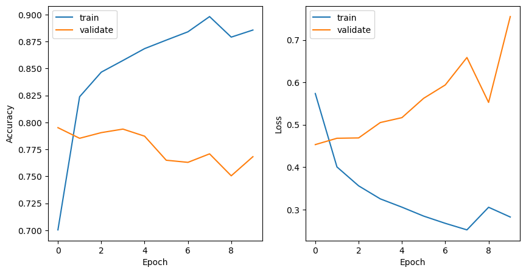

```python
# Visualization:

plt.figure(figsize = (10, 5))

plt.subplot(1, 2, 1)
plt.plot(data['accuracy'])
plt.plot(data['val_accuracy'])
plt.xlabel('Epoch')
plt.ylabel('Accuracy')
plt.legend(['train', 'validate']);

plt.subplot(1, 2, 2)
plt.plot(data['loss'])
plt.plot(data['val_loss'])
plt.xlabel('Epoch')
plt.ylabel('Loss')
plt.legend(['train', 'validate']);
```

```python
# Predictions:

y_pred = lstm_model.predict(X_test, verbose = 1)
y_pred = list(map(lambda x: 0 if x < 0.5 else 1, y_pred))
```

```python
# Report:

print(classification_report(y_test, y_pred))
```

```
              precision    recall  f1-score   support

           0       0.78      0.83      0.81       874
           1       0.75      0.68      0.71       649

    accuracy                           0.77      1523
   macro avg       0.77      0.76      0.76      1523
weighted avg       0.77      0.77      0.77      1523
```

```python
# Evaluation:

lstm_model.evaluate(X_test, y_test)


print('\n\n Accuracy:', accuracy_score(y_test, y_pred))
print('Recall:', recall_score(y_test, y_pred))
print('Precision:', precision_score(y_test, y_pred))
```

```
 Accuracy: 0.768220617202889
Recall: 0.6795069337442219
Precision: 0.7525597269624573
```

```
[[729 145]
 [208 441]]
```

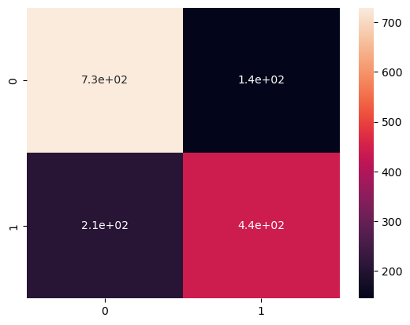

```python
# Confusion matrix and heap map:

con_mat = confusion_matrix(y_test, y_pred)
print(con_mat)

sb.heatmap(con_mat, annot = True);
```

### GRU MODEL:

```python
# Secopnd model:

gru_model = Sequential()

gru_model.add(Embedding(input_dim = 20000, output_dim = 32, input_length = X_train.shape[1]))
gru_model.add(Bidirectional(GRU(units = 40)))
gru_model.add(Dropout(0.1))
#gru_model.add(Dense(10, activation = 'relu'))
gru_model.add(Dense(1, activation = 'sigmoid'))

optimizers = Adam(learning_rate = 0.01) # Optimizer

gru_model.compile(loss = 'binary_crossentropy', optimizer = optimizers, metrics = ['accuracy']) # Compliing

gru_model.summary() # Summary
```

```
Model: "sequential_1"
_________________________________________________________________
 Layer (type)                Output Shape              Param #
=================================================================
 embedding_1 (Embedding)     (None, 19, 32)            640000

 bidirectional (Bidirectiona  (None, 80)               17760
 l)

 dropout_1 (Dropout)         (None, 80)                0

 dense_1 (Dense)             (None, 1)                 81

=================================================================
Total params: 657,841
Trainable params: 657,841
Non-trainable params: 0
_________________________________________________________________
```

```python
# Fit the model:

fit_model = gru_model.fit(X_train, y_train, batch_size = 32, epochs = 10, validation_data = (X_test, y_test))
fit_model
```

```
<keras.callbacks.History at 0x7fb0d92dda00>
```

```python
# Convert to data frame:

data = pd.DataFrame(fit_model.history)
data
```

|  | loss | accuracy | val_loss | val_accuracy |
| --- | --- | --- | --- | --- |
| 0 | 0.499090 | 0.756814 | 0.438060 | 0.795798 |
| 1 | 0.374186 | 0.838588 | 0.489326 | 0.781353 |
| 2 | 0.304724 | 0.875698 | 0.494978 | 0.780039 |
| 3 | 0.238566 | 0.904762 | 0.598560 | 0.767564 |
| 4 | 0.197918 | 0.916420 | 0.697601 | 0.753775 |
| 5 | 0.155666 | 0.937438 | 0.844722 | 0.759028 |
| 6 | 0.132042 | 0.946470 | 0.861879 | 0.747209 |
| 7 | 0.128417 | 0.949261 | 1.005702 | 0.756402 |
| 8 | 0.123797 | 0.950246 | 1.046782 | 0.757715 |
| 9 | 0.109164 | 0.958785 | 1.039382 | 0.732108 |

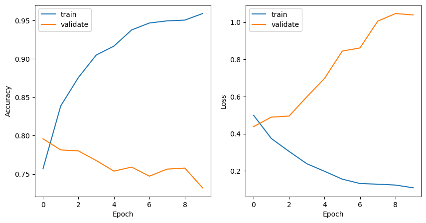

```python
# Visualization:

plt.figure(figsize = (10, 5))

plt.subplot(1, 2, 1)
plt.plot(data['accuracy'])
plt.plot(data['val_accuracy'])
plt.xlabel('Epoch')
plt.ylabel('Accuracy')
plt.legend(['train', 'validate']);

plt.subplot(1, 2, 2)
plt.plot(data['loss'])
plt.plot(data['val_loss'])
plt.xlabel('Epoch')
plt.ylabel('Loss')
plt.legend(['train', 'validate']);
```

```python
# Prediction:

y_pred = gru_model.predict(X_test, verbose = 1)
y_pred = list(map(lambda x: 0 if x < 0.5 else 1, y_pred))
```

```python
# Report:

print(classification_report(y_test, y_pred))
```

```
              precision    recall  f1-score   support

           0       0.77      0.76      0.76       874
           1       0.68      0.70      0.69       649

    accuracy                           0.73      1523
   macro avg       0.73      0.73      0.73      1523
weighted avg       0.73      0.73      0.73      1523
```

```python
# Evaluation:

gru_model.evaluate(X_test, y_test)


print('\n\n Accuracy:', accuracy_score(y_test, y_pred))
print('Recall:', recall_score(y_test, y_pred))
print('Precision:', precision_score(y_test, y_pred))
```

```
 Accuracy: 0.7321076822061721
Recall: 0.6964560862865947
Precision: 0.6817496229260935
```

```
[[663 211]
 [197 452]]
```

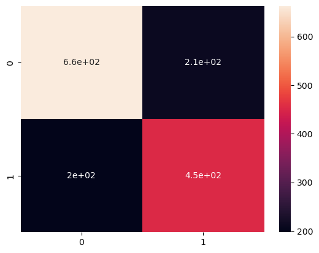

```python
# Confusion matrix and heat map:

con_mat = confusion_matrix(y_test, y_pred)
print(con_mat)

sb.heatmap(con_mat, annot = True);
```

## Results and Analysis:

After preprocess the test data, we can then run each model and submit its predictions to the competition. This had to be done separately but we can see how the models performed in the screenshot below.

```python
# Read test data:

test_data = pd.read_csv('tests.csv', sep = ',')
test_data.head()
```

|  | id | keyword | location | text |
| --- | --- | --- | --- | --- |
| 0 | 0 | NaN | NaN | Just happened a terrible car crash |
| 1 | 2 | NaN | NaN | Heard about #earthquake is different cities, s... |
| 2 | 3 | NaN | NaN | there is a forest fire at spot pond, geese are... |
| 3 | 9 | NaN | NaN | Apocalypse lighting. #Spokane #wildfires |
| 4 | 11 | NaN | NaN | Typhoon Soudelor kills 28 in China and Taiwan |

```python
# Drop keyword and location varibale:

test_data.drop(['keyword', 'location'], axis = 1, inplace = True)
```

```python
# Drop duplication:

test_data.drop_duplicates(inplace = True)
```

```python
# Size:

test_data.shape
```

```
(3263, 2)
```

```python
# Model Tokenization:

test_data['text'] = test_data.text.apply(tokenize)
test_data.sample(5)
```

|  | id | text |
| --- | --- | --- |
| 2014 | 6778 | democracy |
| 605 | 1977 | soaring temperature southern u state causing b... |
| 2327 | 7786 | trending nigeria police charge traditional rul... |
| 1794 | 6062 | heat wave social autopsy disaster chicago klin... |
| 217 | 703 | christian attacked muslim temple mount waving ... |

```python
# Model Tokenization:

tokenizer = Tokenizer(num_words = 2000, split = ' ')
tokenizer.fit_on_texts(test_data.text.values)

X = tokenizer.texts_to_sequences(test_data.text.values)
X = pad_sequences(X)

print(X[:5])

print('\n \n', tokenizer.sequences_to_texts([[494, 850, 53, 39]]))

tokenizer.sequences_to_texts(X)[:5]
```

```
[[   0    0    0    0    0    0    0    0    0    0    0    0  497  852
    53   39]
 [   0    0    0    0    0    0    0    0    0  183  210 1675  121  615
   762  330]
 [   0    0    0    0    0    0    0    0    0   63    1  763 1359  853
   369  184]
 [   0    0    0    0    0    0    0    0    0    0    0    0    0    0
   185   87]
 [   0    0    0    0    0    0    0    0    0    0    0  408  689   76
   331 1360]]


 ['rioting bestnaijamade car crash']
```

```
['happened terrible car crash',
 'heard earthquake different city stay safe everyone',
 'forest fire spot pond across street save',
 'apocalypse wildfire',
 'typhoon soudelor kill china taiwan']
```

```python
# Prediction:

pred = lstm_model.predict(X)
pred
```

```
array([[0.8338962 ],
       [0.8426496 ],
       [0.21445675],
       ...,
       [0.02080371],
       [0.97182584],
       [0.808779  ]], dtype=float32)
```

```python
# Creating submission model:

submission_df = pd.DataFrame({'id': test_data.id, 'target': list(map(lambda x: 0 if x < 0.5 else 1, pred))})
submission_df
```

|  | id | target |
| --- | --- | --- |
| 0 | 0 | 1 |
| 1 | 2 | 1 |
| 2 | 3 | 0 |
| 3 | 9 | 0 |
| 4 | 11 | 1 |
| ... | ... | ... |
| 3258 | 10861 | 0 |
| 3259 | 10865 | 0 |
| 3260 | 10868 | 0 |
| 3261 | 10874 | 1 |
| 3262 | 10875 | 1 |

3263 rows × 2 columns

```
0    1882
1    1381
Name: target, dtype: int64
```

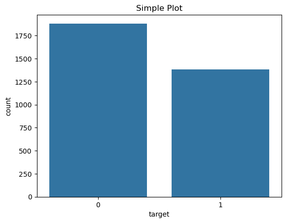

```python
# Visualization:

color = sb.color_palette()[0]

val = submission_df.target.value_counts()
print(val)

sb.countplot(data = submission_df, x = 'target', color = color);
plt.title('Simple Plot');
plt.ylabel('count');
plt.xlabel('target');
```

```python
# Submit data:

submission_df.to_csv('submission.csv', index = False)
```

The first model using LSTM techniques got an F1 score of 0.556, which is better than the GRU model which got an F1 score of 0.541 on the test set. These values are a bit better than randomly guessing.

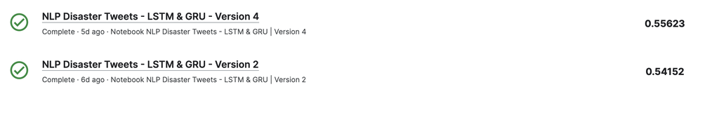

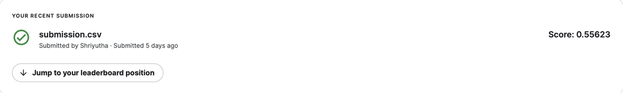

## Conclusion:

Firstly we have imported the training dataset and analyzed it. We also visualized much of the data too. Then we preprocessed the training data and modified the text by making it easier for a computer to understand. After we had the training data ready, we split the training data into two subsets; training and validation, so that we could better train our models. Then we trained two models; LSTM and GRU. Finally, we tested both models on the testing set and found our F1 score in the Kaggle competition page.